# Mouse Forecast

Current season

House mouse activity across Australian grain-growing regions

## Overview

- Western Australia: Mice are widespread in the Geraldton and Esperance regions, particularly in canola, with damage reported. While the plague has slowed, it doesn’t appear to have crashed, and recent rainfall has been exceptionally favourable for mice. Mouse plagues can extend into a second year, so growers should keep monitoring closely.
- South Australia: A quick swing from a dry period to above-average rainfall, which tends to come before plagues, has recently occurred across the Mid North, Yorke and Eyre Peninsulas, and the Mallee. Mouse numbers are still low, but activity in cereal crops in the Mid North and Yorke Peninsula is slightly above normal for this time of year, so we are watching these regions closely. The Mallee remains quiet.
- Victoria and NSW: Activity is slightly above normal in the Wimmera and South East NSW. Growers should check paddocks through spring.
- Queensland: Mice are present in some ripening winter crops and sorghum stubble paddocks in South East Queensland heading into spring. Growers sowing summer crops should check paddocks, and neighbouring stubble, before planting.
- Elsewhere: mouse activity is low or at normal levels for this time of year.

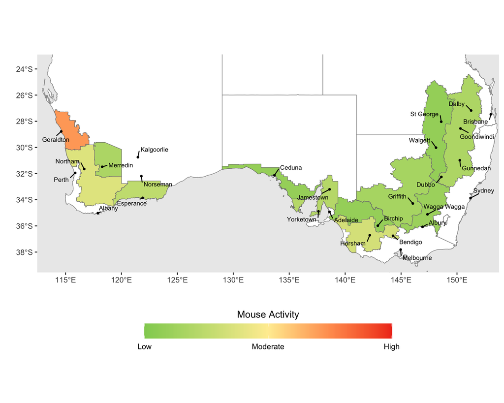

Figure 1: Estimated relative mouse activity in Spring 2026 (September - November) across each GRDC agro-ecological zone (broad regions defined by similar climate, soils, and farming systems). Estimates consider live-trapping rates, active burrow counts, chew card assessments, the proportion of surveyed paddocks which detected mice and farmer observations (via MouseAlert).

## Management recommendations

- Monitor mouse activity in crops before harvest, particularly in WA’s Geraldton and Esperance regions, SA’s Mid North and Yorke Peninsula, the Wimmera, South East NSW and South East Queensland, and decide early whether baiting is needed.
- Monitor using chew cards or a walk-through checking for crop damage (https://grdc.com.au/resources-and-publications/resources/mouse-management/monitor-manage/know-your-mouse-numbers). Active burrow counts are generally less reliable at this time of year.
- If you find mice or damage, consider applying zinc phosphide bait (https://grdc.com.au/resources-and-publications/resources/mouse-management/monitor-manage/mouse-baiting) before crops mature. Bait becomes less attractive once grain develops in the head, so baiting ripening crops is unlikely to be effective.
- Growers sowing summer crops should check paddocks and neighbouring stubble before planting, and consider baiting at or immediately after sowing if mice are present.
- ZnP25 is registered nationally. Use it according to the label and report any adverse effects via the APVMA website (https://www.apvma.gov.au/regulation/adverse-experience-reporting-program). An emergency permit currently allows use of the higher-dose ZnP50 bait. Check where it applies, its conditions and its expiry on the GRDC website (https://grdc.com.au/resources-and-publications/resources/mouse-management).
- Aim for a clean harvest with minimal grain loss to reduce food for mice in stubble, and keep monitoring after harvest, as mouse numbers then set the risk for next season’s sowing.

## Past trends

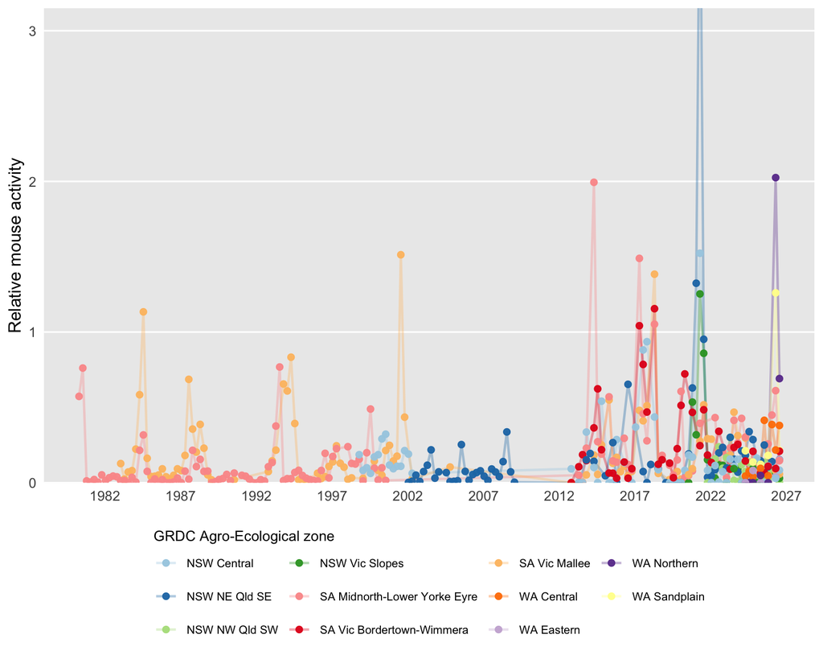

Figure 2: Estimated relative mouse activity from Autumn 1980 - Winter 2026 in each GRDC agro-ecological zone (broad regions of the Australian grain belt defined by similar climate, soils, and farming systems). Estimates consider live-trapping rates, active burrow counts, chew card assessments, the proportion of surveyed paddocks which detected mice and farmer observations (via MouseAlert).

## About

Mouse forecasts are enabled through a [Grains Research and Development Corporation and CSIRO investment into the 2025-29 Mouse Monitoring and Surveillance project](https://groundcover.grdc.com.au/grdc/announcements/investments-target-new-normal-of-mouse-activity) via the [Rodent Pest Management team](https://research.csiro.au/rm/). Forecasts will be updated seasonally or as new data becomes available.

We are actively developing new statistical models to improve mouse forecasts, and working on their presentation. This work is run in coordination with the National Mouse Group, a grower-led network of farmers, industry representatives, state government, GRDC and CSIRO. The group meets three times a year to update local reports of the current mouse situation, review management recommendations and determine research priorities.

### Monitoring data

Mouse population surveys are conducted 2 - 3 times a year at each of the ~170 long-term monitoring sites. Mice are surveyed through active burrow searches and chew cards. To calibrate this data against more robust population density measurements, we also conduct live-trapping at 3 sites (Adelaide Plains SA, Northern Mallee VIC and Central West NSW).

Mouse monitoring data is collected by CSIRO, NSW Local Land Services, NSW Department of Primary Industries and Regional Development, Central West Farming Services, Birchip Cropping Group, and Farmanco. We also thank NSW DPIRD, who generously provide additional live-trapping survey data. Further live-trapping data is also occasionally supplied through the [GRDC / CSIRO Mouse Ecology 2024-2029 project](https://research.csiro.au/rm/research-projects/mouse-ecology-2024-2029/).

We also receive reports from farmers, agronomists and other community members directly. This is key information we consider given we cannot feasibly survey every paddock across the entire grain growing region.

## Report mouse activity

Take 60 seconds to report mouse activity on your farm on [MouseAlert](https://feralscan.org.au/mousealert).

We are primarily seeking observations from within paddocks (not houses or farm sheds), and particularly encourage reporting of low activity - not just observations of high mouse activity.

We incorporate these observations with our monitoring survey results to create these forecasts and improve understanding of mouse populations, to help keep producers informed.

## Contact

Questions about the forecast? Get in touch with Dr Matthew Rees matt.rees@csiro.au.

For media enquiries, contact Research Officer Steve Henry steve.henry@csiro.au or the [CSIRO media office](https://www.csiro.au/en/news/Media-Centre).

We value your feedback.

## 📬 Stay updated

Receive seasonal mouse forecasts to your inbox